# R and RStudio

yoshito.nishio+JNPC@gmail.com

2018/9/22

# RとRStudioの使い方

### Rって何？

「R」は統計処理に強いプログラム言語で、フリーソフト。  
素のままでは取っつきにくいので、使い勝手をよくする「RStudio」上で使うことを、強くお勧めする。  
右上の「＋」ボタンで「R Script」を選んで新規作成するとエディターペインが開くので、そこにコードを書いていく。小さなまとまりごとに実行してみて、辛抱強くエラーを取り除きながら……。なお、RはExcelとは違って、大文字と小文字を区別することに注意。RStudioには補完機能があり、入力の途中で`Tab`を押すと、候補を表示してくれる。  
今からRを始める方は、Rのもともとの関数よりもさまざまな点で優れている、「`tidyverse`」というパッケージソフトを使うとよい。一貫性があるので、覚えやすい。

### Rを使うメリット

裏を返せば、Excelのデメリット。  
Rはデータと処理が分離されている。食材とレシピが分離されているイメージ。同じ料理を繰り返し提供できる「再現可能性」が高い。何をしているのか、他人が見ても流れが追いやすいし、点検やメンテナンスがしやすい。  
Excelはデータと処理が渾然一体となっている。料理の完成品だけがあっても、もう一度同じものを作れる保証はない。再現可能性が低く、あとから（何をやったか自分でも忘れたころに）手直しするのも大変。  
NICARで講師を務めた The Guardian の記者からは

> Rなら、専門家にコードとデータを送って、自分の分析が間違っていないか検証してもらうことができるのが強み。私がRを始めた理由はこれ

と教わった。  
デメリットは、日本語の扱いがまだ、こなれていないこと。RStudioで日本語を打つのはやりにくいし、後出のプロジェクト名に日本語を使うのは避けた方がよいらしい。また、Macの場合はプロットの文字化け対策に一手間かかる。  
きょうは、デフォルトでは不可視設定の「.Rprofile」というファイルに、極力文字化けを防ぐ設定が入っている。Rの第一人者、石田基広先生のgithubからのもの。また、全員で同じデータを読む都合上、プロジェクト（本日用の環境設定）で、文字コードを「UTF-8」に決め打ちしている。

### RStudioの画面構成

田んぼの「田」みたいなペイン。左下（エディターを使っていないときは左半分全部）がRの実行画面で、コンソールという。左上は、Rのコードを書いて保存するためのエディター。右上は今使っている変数のリストや履歴など。右下はプロットが出力されたり、ヘルプが開いたり。  
基本は、左上の画面でRのコードを書き、「Ctrl + Enter」でカーソルのある行またはブロックの命令を実行（左下のコンソールに送られる）。全体を一度に実行するなら、Rmd形式（説明のマークダウンとRのコードが混在している、このファイルの形式。「Knit」ボタンでHTMLにできる）のときは、上の「Run」から「Run All」を選ぶ。Rスクリプト（コードのみ。拡張子がR）なら、Runの右隣の「Source」。

### パッケージのインストール

素のままのRに入っていない、オプションのものを使うときには、「パッケージのインストール」と「読み込み」が必要。インストールは最初に１度だけすればよいが、読み込みはRを起動するたびにしなくてはならない。  
きょうも使う２つのパッケージで練習してみる。  
なお、`#`から後は、プログラムとしては実行されない、コメントになる。将来の自分のために、まめに説明を残しておくとよい。  
あるいは、今は使わないけれど、必要になるかもしれない命令を、消さずに取っておくためにコメントにしておく。実行するときは、`#`を消す。「Shift + Control + C」で、コメントになったり、元に戻ったり、切り替わる。

```r
# 最初の１回だけ、この下２行の「#」を削って「install.packages」を実行して。２回目からは不要

# install.packages("tidyverse")
# install.packages("GGally")

# この下の２行は、このパッケージを使うなら、Rを起動するたびに実行して。requireの代わりにlibraryでもいい。
require(tidyverse)
require(GGally)
```

うまく行っただろうか？ 「××が見つかりません」という類のエラーメッセージが出た方は、お知らせを。見つからない、と言われたパッケージを`install.packages("そのパッケージ名")`でインストールすると、解決することが多い。

### スカラー、ベクトル、データフレーム

Rは、データの塊を一括処理するのが得意。Excelで言えば、セル１つに当たるものを個別に扱うだけでなく、１列まとめてや、シート１枚丸ごとに同じ処理を適用することができる。最後の縦横２次元になったデータの組を、データフレームとRでは呼んでいる。

```r
# データの入れ物を変数という
# 数字を１つ入れてみる
hensuu0 <- 12345
# 左向き矢印（不等号とマイナス）が代入。「Altとマイナスの同時押し」で出る。MacではAltではなく「option」
# 他のプログラム言語のように、イコールでも代入できる。ちなみに「等しい」はイコール２つ（==）で表す

# 中身を見るには、変数名を入力すればよい
hensuu0
```

```
## [1] 12345
```

```r
# c()はベクトルを作る命令。combineの意
hensuu1 <- c(1, 2, 3, 4, 5)
hensuu1
```

```
## [1] 1 2 3 4 5
```

```r
# hensuu1のすべての要素に、hensuu0を足す
hensuu1 + hensuu0
```

```
## [1] 12346 12347 12348 12349 12350
```

```r
# * はかけ算の記号
hensuu1 * hensuu1
```

```
## [1]  1  4  9 16 25
```

```r
# ５つの数がそれぞれ２乗された

# データフレームの例
hensuu2 <- data.frame(hensuu1, hensuu1 * 2, hensuu1 * 2)
hensuu2
```

```
##   hensuu1 hensuu1...2 hensuu1...2.1
## 1       1           2             2
## 2       2           4             4
## 3       3           6             6
## 4       4           8             8
## 5       5          10            10
```

```r
# 列に項目名をつけるなら
hensuu2 <- data.frame(first = hensuu1, second = hensuu1 * 2, third = hensuu1 * 3)
hensuu2
```

```
##   first second third
## 1     1      2     3
## 2     2      4     6
## 3     3      6     9
## 4     4      8    12
## 5     5     10    15
```

`head()`と`tail()`でデータの先頭部分と末尾部分だけを見られる。  
RStudioのビューアーで、Excelのシートのように見るには、`View(変数名)`のようにする。Vは大文字。

列を取り出すなら、`$`の後に項目名をつける。とりあえず、このやり方だけ覚えておく。

```r
hensuu2$second
```

```
## [1]  2  4  6  8 10
```

```r
# 数字で指定することもできる。１列目と３列目（すべての行）
hensuu2[ , c(1, 3)]
```

```
##   first third
## 1     1     3
## 2     2     6
## 3     3     9
## 4     4    12
## 5     5    15
```

```r
# ３行目から５行目の、firstとthird列
hensuu2[3:5, c("first", "third")]
```

```
##   first third
## 3     3     9
## 4     4    12
## 5     5    15
```

### プロジェクト

まず「プロジェクト」というものを作ってから、作業に取りかかるとよい。分析に関するもの一式をディレクトリーにまとめ、整理して管理するのに役立つ。左上の２番目の「＋」ボタンで作れる。既存のディレクトリーを指定しても、新規作成してもよい。  
きょうは、このファイルも入っている「R_script」というディレクトリーに、プロジェクトを設定しておいた。  
今の作業場所がどこかは、`getwd()`で調べられる。データを読み込むときのパスは、ここを基準にして指定する。同じ階層のdataフォルダのものなら、「`../data/ファイル名`」。最初の「`..`」で１階層上の「JNPC-master」に上がってから、「data」フォルダに降りている。同じ階層の横のフォルダを直接指定することはできないので、共通の親まで遡ってから。

### ファイルの読み込み

`read_csv()`を使う。紛らわしいが、ドットではなく、アンダースコアのほう。こちらが進化形。`tidyverse`パッケージを呼び込んでいないと使えない。  
ファイルのパスを指定する。もし、CP932の文字コードのファイルを読むなら、その指定「`, locale = locale(encoding = 'CP932')`」をつける。パスを指定せずに、ダイアログで選ぶ方法もある。これはよく使う。余裕があったら、以下のコメントの＃を外して試してみて。

```r
climate18 <- read_csv("../data/climate18.csv")
head(climate18)
```

```
## # A tibble: 6 x 7
##   date_hour temperature humidity wind_velocity wind_direction precipitation
##   <chr>           <dbl>    <int>         <dbl> <chr>                  <dbl>
## 1 2018/7/1…        26.4       86           5.4 S                          0
## 2 2018/7/1…        26.1       88           3.7 S                          0
## 3 2018/7/1…        25.8       89           4.1 S                          0
## 4 2018/7/1…        25.6       90           3.7 S                          0
## 5 2018/7/1…        25.7       90           3.2 SSW                        0
## 6 2018/7/1…        26.1       89           3.9 S                          0
## # ... with 1 more variable: no_precipitation_dummy <int>
```

```r
# S-JISで読み込むなら、以下のようにエンコードを指定
cafe_sjis <- read_csv("../data/cafe_data_sjis.csv", locale = locale(encoding = 'CP932'))
head(cafe_sjis)
```

```
## # A tibble: 6 x 7
##   コード 都道府県    人口  世帯数 スタバ ドトール コメダ
##   <chr>  <chr>      <int>   <int>  <int>    <int>  <int>
## 1 01     北海道   5339539 2772845     35       25      8
## 2 02     青森県   1308707  591371      9       13      0
## 3 03     岩手県   1264329  524685      8        9      1
## 4 04     宮城県   2312080  989296     22       27      5
## 5 05     秋田県   1015057  425933      7        2      1
## 6 06     山形県   1106984  413685      7       12      3
```

```r
tail(cafe_sjis)
```

```
## # A tibble: 6 x 7
##   コード 都道府県      人口   世帯数 スタバ ドトール コメダ
##   <chr>  <chr>        <int>    <int>  <int>    <int>  <int>
## 1 43     熊本県     1789184   776133     10        3      5
## 2 44     大分県     1169158   535794      7        2      4
## 3 45     宮崎県     1112008   523791      5        4      4
## 4 46     鹿児島県   1655888   807682      5        5     10
## 5 47     沖縄県     1471536   643056     21        7      1
## 6 NULL   合計     127707259 58007536   1354     1338    808
```

```r
# ダイアログボックスが開くので、どれでもよいからCSV形式のファイルを選んでみて
# suki_na_CSV <- read_csv(file.choose())
# head(suki_na_CSV)
```

### 相関係数

`cor()`を使う。かっこ内は(X列のデータ,Y列のデータ)。最初から２列分まとまったデータフレームになっていれば、それでもよい（そのほうがよい）。３列以上だとどうなるだろう？

```r
# まず、全国計は抜いておく。都道府県の列の値が「合計」である行は不要、という指示。!=は等しくない、の意味
cafe_sjis <- cafe_sjis[cafe_sjis$都道府県 != "合計", ]
# ２列だけ取り出して、相関係数を計算した
cor(cafe_sjis$人口, cafe_sjis$世帯数)
```

```
## [1] 0.9958649
```

```r
# 数値の列だけを取り出して、cafeという新しいデータフレームに保存した。tidyverseの命令を使っている
# どれとどれの相関が強いか、まとめて見てみる。対角線を挟んで右上と左下は同じ
cafe <- cafe_sjis %>%
  select(人口, 世帯数, スタバ, ドトール, コメダ)
cor(cafe)
```

```
##               人口    世帯数    スタバ  ドトール    コメダ
## 人口     1.0000000 0.9958649 0.9075932 0.8215810 0.5311797
## 世帯数   0.9958649 1.0000000 0.9293525 0.8547759 0.4919809
## スタバ   0.9075932 0.9293525 1.0000000 0.9668493 0.4412150
## ドトール 0.8215810 0.8547759 0.9668493 1.0000000 0.2686937
## コメダ   0.5311797 0.4919809 0.4412150 0.2686937 1.0000000
```

こういった処理結果を、変数に代入して保存しておくことができる。そうすれば、あとでまた、呼び出して中身を見たり、さらに加工したりできる。

### 散布図

その前に、散布図を見ておくべきなのだった。見栄えにこだわらないなら、`plot()`でいい。これもXとY、または、もっとたくさん指定できる。

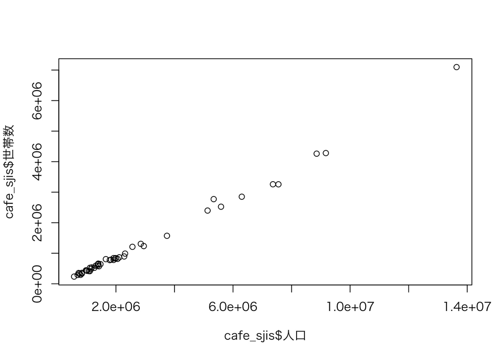

```r
# XとYを指定した
plot(cafe_sjis$人口, cafe_sjis$世帯数)
```

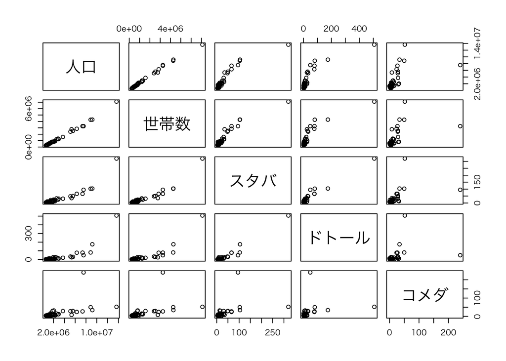

```r
# 数値データをまとめて渡した
plot(cafe)
```

数値やカテゴリー（内部形式では数値）でないものが入るとエラーする。

### ggplot2

見栄えがよいのは、「`ggplot2`」パッケージを使う方法。いったん変数に保存する方法でやってみる。丁寧に書いているが、「`data =`」と「`mapping =`」は、慣れてきたら入力しなくてもよい。

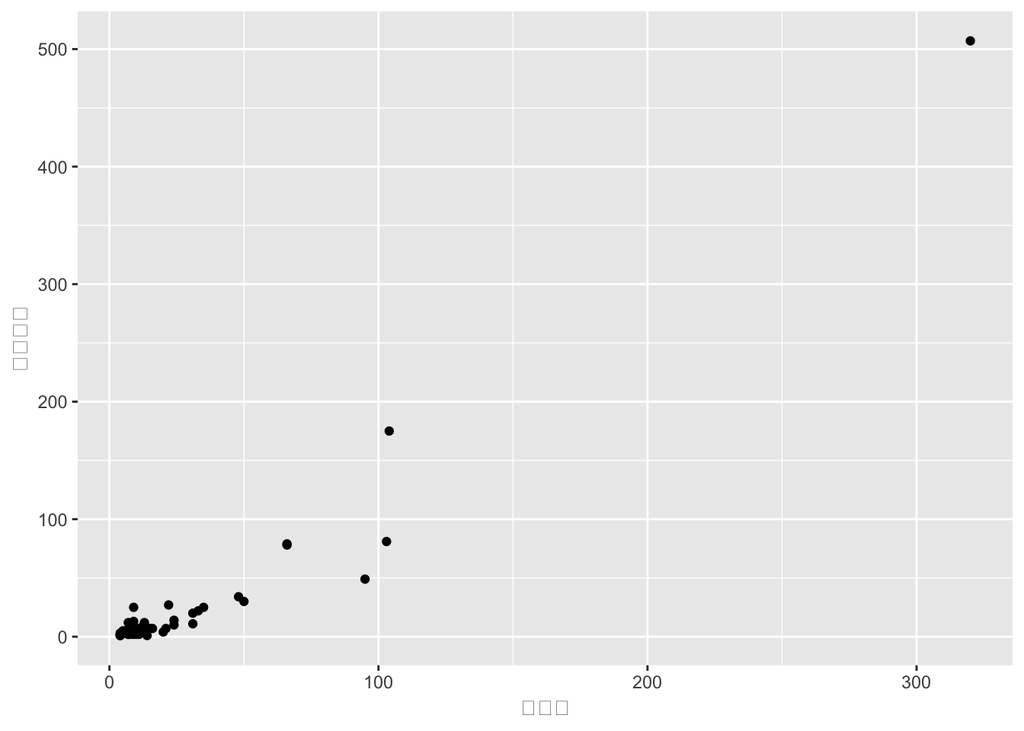

```r
star_doutor <- ggplot(
  data = cafe,
  mapping = aes(x = スタバ, y = ドトール)
) + geom_point()
# それを表示
star_doutor
```

Macでは文字化けしているのでは？ その対策を１行追加し、書き方は簡略化した。

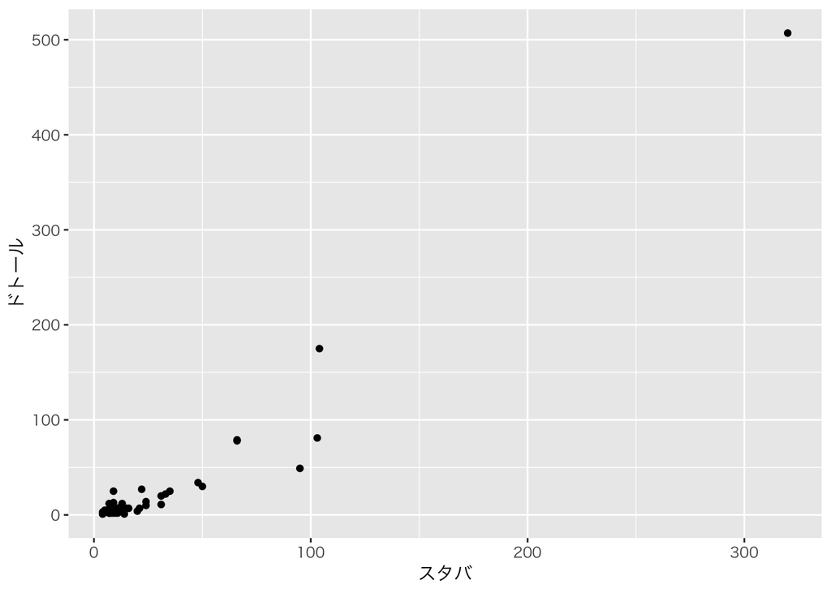

```r
old = theme_set(theme_gray(base_family="HiraKakuProN-W3")) # この１行はWindowsでは不要
star_doutor <- ggplot(cafe, aes(x = スタバ, y = ドトール)) +
  geom_point()
star_doutor
```

画像の保存にもハードルがある。とりあえず、画像をクリックするか、もしくは右下のプロットペインから、「Download Image」か「Export」を選ぶ。

２項目だけでなく、たくさんの項目について、一度に見たいときは、`GGally`パッケージの「`ggpairs`」を使う。少し時間がかかる。

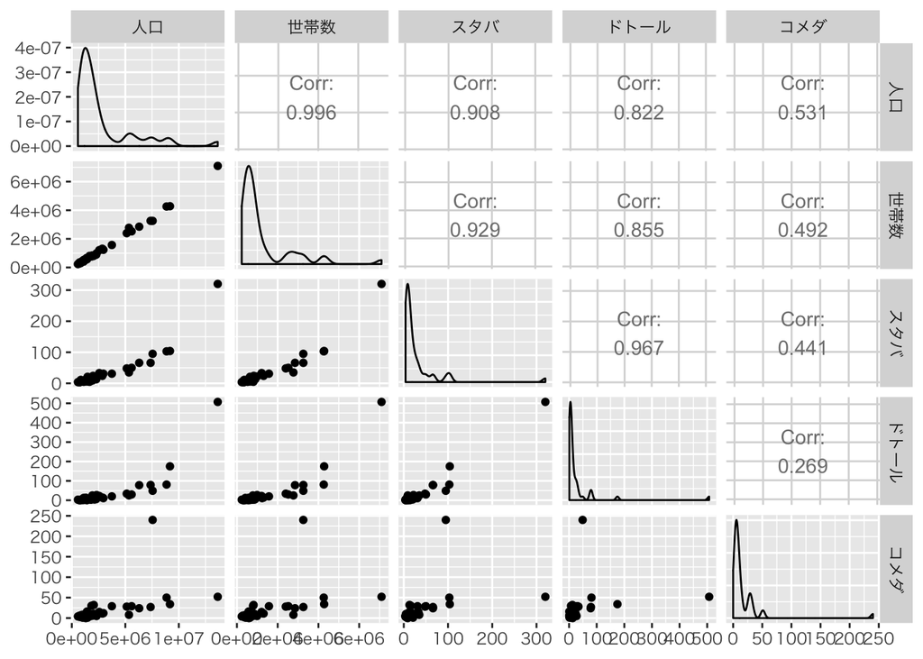

```r
ggpairs(cafe)
```

### 回帰直線

`lm()`を使う。linear modelの意。中には「フォーミュラ」と呼ばれる式を書く。説明・予測したい変数、「~」、説明に使う変数、使うデータセット名。説明に使う変数を複数にすれば、重回帰分析。

```r
# 人口と世帯の２列だけにする。
cafe2 <- cafe_sjis[ , c("人口","世帯数")]
head(cafe2)
```

```
## # A tibble: 6 x 2
##      人口  世帯数
##     <int>   <int>
## 1 5339539 2772845
## 2 1308707  591371
## 3 1264329  524685
## 4 2312080  989296
## 5 1015057  425933
## 6 1106984  413685
```

```r
# これはtidyverseを使うやり方で、同じ結果になる。好みで、どちらを使ってもよい
cafe2 <- cafe_sjis %>%
  select(人口, 世帯数)
head(cafe2)
```

```
## # A tibble: 6 x 2
##      人口  世帯数
##     <int>   <int>
## 1 5339539 2772845
## 2 1308707  591371
## 3 1264329  524685
## 4 2312080  989296
## 5 1015057  425933
## 6 1106984  413685
```

```r
# 単回帰分析をする
cafe_lm <- lm(世帯数 ~ 人口, cafe2)
cafe_lm
```

```
##
## Call:
## lm(formula = 世帯数 ~ 人口, data = cafe2)
##
## Coefficients:
## (Intercept)         人口
##  -1.012e+05    4.915e-01
```

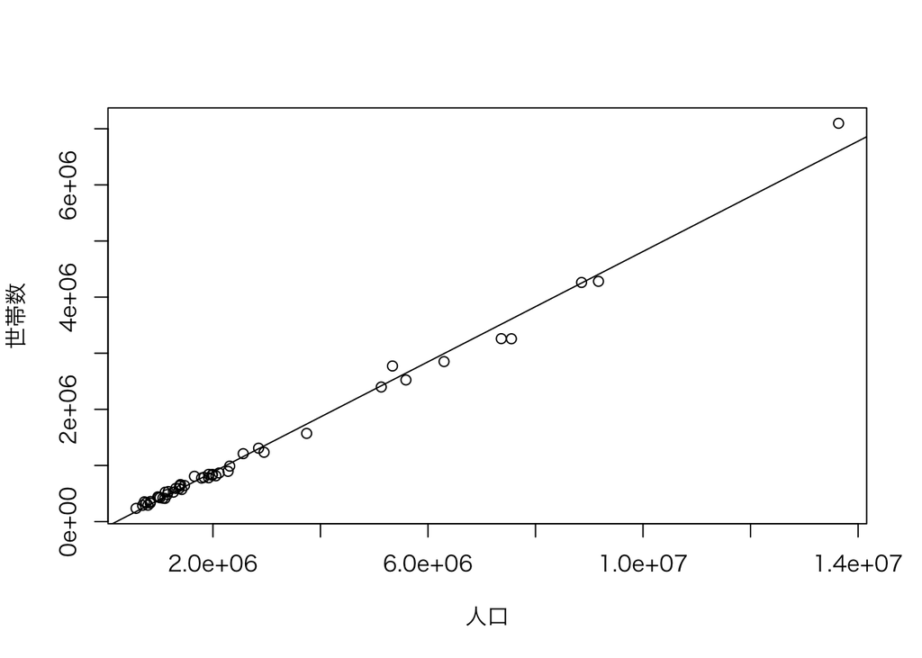

```r
# 散布図に回帰直線を重ねる
plot(cafe2)
abline(cafe_lm)
```

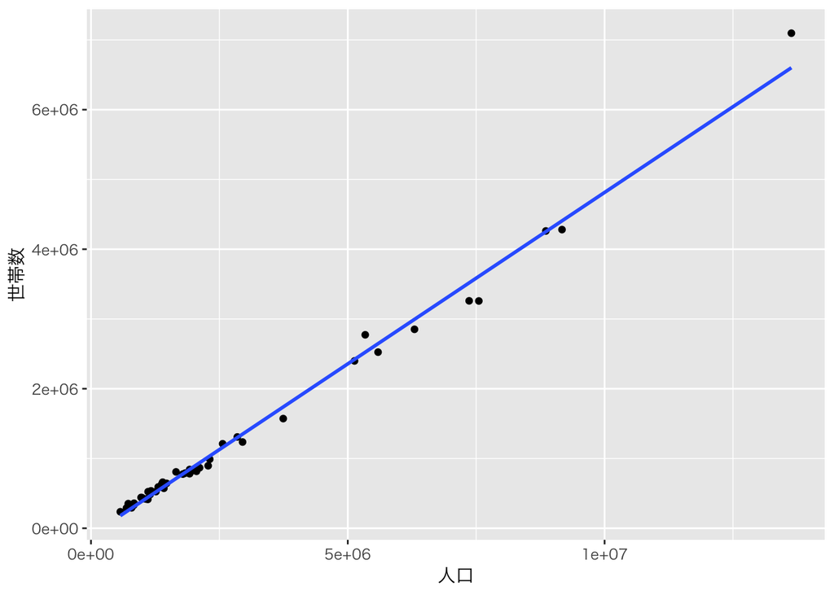

```r
ggplot(cafe, aes(x = 人口, y = 世帯数)) +
  geom_point() +
  geom_smooth(method = lm, se = FALSE)
```

`ggplot2`の場合、回帰直線を追加で引くだけなら、「`+ geom_smooth()`」を加えればよい。ただし、いろいろな近似曲線をひく機能があるので、「`method = lm, se = FALSE`」を指定して、線形近似で標準誤差表示なし、にした。  
係数を知るには、やはり`lm()`で。

### 参考資料

ショートカットキーの一覧を別ファイルに。  
上のメニュー欄の「Help」から「Cheatsheets」→「RStudio IDE Cheat Sheet」とたどると、表裏１枚のアンチョコがある。  
Rはネットに先達の情報が豊富にあるが、入門に向いているのは、三重大の奥村晴彦先生のサイト [「Rの初歩」](https://oku.edu.mie-u.ac.jp/~okumura/stat/first.html) 。  
データの可視化によく使う「ggplot2」については、総研大の岩嵜航さん（Heavy Watalさん）のスライド [「Rにやらせて楽ラクしよう ーー データの可視化と下ごしらえ」](https://heavywatal.github.io/slides/nagoya2018/2-ggplot.html) がとても参考になる。前後の回も、ぜひ。  
紙の書籍なら、石田基広先生がおすすめ。